# ATHENS course on Extreme-Value Theory

Multivariate extreme-value analysis

Thomas Opitz (BioSP, INRAE)

16 March 2022

##Practicals Part 1

### 1.1) Simulation and visualisation of the pairwise beta angular measure

We sample from the spectral measure using the function rpairbeta, and then we provide an interactive 3D plot with plot3d. We can also add the boundary segments of the unit simplex, and the origin (0,0,0).

First, we load the required R packages.

```r
#library containing the pairwise beta angular measure:
library(BMAmevt)
#library for "3D Visualization Using OpenGL":
#options(rgl.useNULL = TRUE)
#options(rgl.printRglwidget = TRUE)
library(rgl)
```

```r
n=200
pars=c(0.5,0.2,0.2,6)
w=rpairbeta(n,dimData=3,par=pars)
plot3d(w,xlab=expression(w[1]),ylab=expression(w[2]),zlab=expression(w[3]))
rglwidget()
```

[interactive chart not shown]

```r
pars=c(.1,10,10,10)
w=rpairbeta(n,dimData=3,par=pars)
plot3d(w,xlab=expression(w[1]),ylab=expression(w[2]),zlab=expression(w[3]))
segments3d(c(1,0),c(0,1),c(0,0),col="blue")
segments3d(c(1,0),c(0,0),c(0,1),col="blue")
segments3d(c(0,0),c(0,1),c(1,0),col="blue")
points3d(0,0,0,col="blue",size=10)
rglwidget()
```

[interactive chart not shown]

```r
pars=c(25,10,10,10)
w=rpairbeta(n,dimData=3,par=pars)
plot3d(w,xlab=expression(w[1]),ylab=expression(w[2]),zlab=expression(w[3]))
segments3d(c(1,0),c(0,1),c(0,0),col="blue")
segments3d(c(1,0),c(0,0),c(0,1),col="blue")
segments3d(c(0,0),c(0,1),c(1,0),col="blue")
points3d(0,0,0,col="blue",size=10)

pars=c(.1,.1,.1,.1)
w=rpairbeta(n,dimData=3,par=pars)
plot3d(w,xlab=expression(w[1]),ylab=expression(w[2]),zlab=expression(w[3]))
segments3d(c(1,0),c(0,1),c(0,0),col="blue")
segments3d(c(1,0),c(0,0),c(0,1),col="blue")
segments3d(c(0,0),c(0,1),c(1,0),col="blue")
points3d(0,0,0,col="blue",size=10)

pars=c(25,.1,.1,.1)
w=rpairbeta(n,dimData=3,par=pars)
plot3d(w,xlab=expression(w[1]),ylab=expression(w[2]),zlab=expression(w[3]))
segments3d(c(1,0),c(0,1),c(0,0),col="blue")
segments3d(c(1,0),c(0,0),c(0,1),col="blue")
segments3d(c(0,0),c(0,1),c(1,0),col="blue")
points3d(0,0,0,col="blue",size=10)
```

### 1.2) Empirical estimation of an extreme event probability

We first define the function ell.min that appropriately reweights the angles of w. Then, we can empirically estimate the target probabilities.

```r
ell.min=function(w,u){min(w/u)}
pars=c(5,1,1,1)
w=rpairbeta(n,dimData=3,par=pars)
3/n*sum(apply(w,1,ell.min,u=10))
```

```
## [1] 0.04647335
```

```r
pars=c(.1,1,1,1)
w=rpairbeta(n,dimData=3,par=pars)
3/n*sum(apply(w,1,ell.min,u=10))
```

```
## [1] 0.008759843
```

## Practicals Part 2: Dependence summaries of air pollution data

### Description (recall of Day 1 practicals)

We first load the data object and display its first and last lines.

```r
load("nitrogenDioxideMsmts.RData")
dim(no2Msmts)
```

```
## [1] 4497    6
```

```r
head(no2Msmts)
```

```
##   date      alx      arl        mc       rt       ts
## 1 9162 48.94594 40.02866 44.394349 41.51378 41.44504
## 2 9163 36.89465 36.48012 32.839171 35.87481 35.16941
## 3 9164 38.98373 44.07211 39.801299 40.08453 38.58505
## 4 9165 34.41888 31.91026 26.643805 31.29779 29.14976
## 5 9166 17.34388 14.71787  5.918686 12.71006 11.78087
## 6 9167 34.01735 32.12474 33.940509 31.13621 21.81810
```

```r
tail(no2Msmts)
```

```
##       date      alx      arl       mc       rt       ts
## 4631 14635 26.86159 24.84220 26.10330 28.25237 26.56204
## 4632 14636 38.20120 32.46180 37.88082 38.51873 36.11601
## 4633 14637 31.54337 28.05154 42.41072 34.67496 41.32923
## 4634 14638 23.26186 10.96069 14.56890 21.55876 16.49128
## 4635 14639 25.54794 19.02271 20.27997 21.12096 19.73806
## 4636 14640 51.28440 44.88402 43.02091 49.27270 45.42105
```

For simplicity, we will ignore seasonal and long-term trends in the time series and proceed as if data vectors were independent and identically distributed over time. We extract the five data columns into a matrix, and then we show pairwise scatterplots.

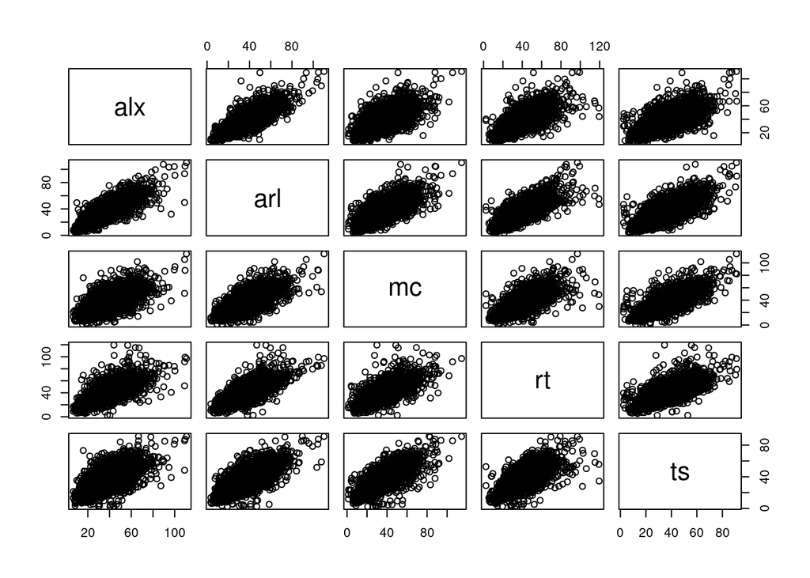

```r
mydata=no2Msmts[,-1]
pairs(mydata)
```

### 2.1) Marginal standardization based on the rank transform

We now transform the data to standardized margins (standard Pareto here) using the empirical probability distribution, that is, we use the so-called rank transform.

```r
n=nrow(mydata)
myranks=apply(mydata,2,rank)
data.unif=myranks/(n+1)
data.stand=1/(1-data.unif)
```

### 2.2) Estimation of the extremal coefficient

We estimate the extremal coefficient for a range of values. To obtain symmetric confidence intervals, we use a simple estimator of the standard deviation (that disregards the uncertainty coming from the marginal pretransformation to the standard Pareto scale).

```r
p=0.8+0:19*0.01
u.star=1/(1-p)
u.star[1]*mean(apply(data.stand>u.star[1],1,any))
```

```
## [1] 1.892373
```

```r
u.star[20]*mean(apply(data.stand>u.star[20],1,any))
```

```
## [1] 3.068712
```

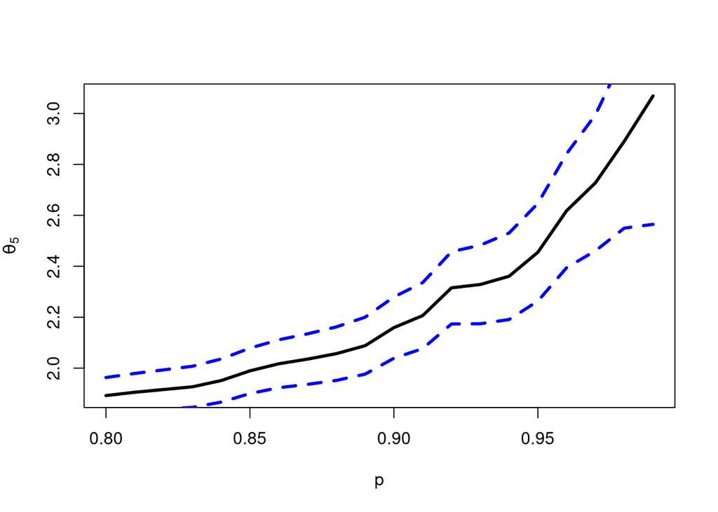

```r
theta.est=c()
for(i in 1:length(p)){
  theta.est[i]=u.star[i]*mean(apply(data.stand>u.star[i],1,any))
}
plot(p,theta.est,type="l",lwd=3,xlab="p",ylab=expression(theta[5]))
# calculate approximate 95% pointwise confidence intervals
sd_est = sqrt(u.star/n * theta.est *(1-theta.est/u.star))
lines(p,theta.est + qnorm(.975)*sd_est, col = "blue", lwd = 3, lty = 2)
lines(p,theta.est - qnorm(.975)*sd_est, col = "blue", lwd = 3, lty = 2)
```

Judging from the significantly increasing estimates when p increases, the data do not show threshold-stability. We seem to be in the situation of asymptotic independence.

### 2.3) Estimation of the coefficient of tail dependence

Next, we plot the estimates of the coefficient of tail dependence, estimated using the Hill estimator applied to the sample of the minimum of the 5 components. This can be done conveniently with the hillPlot function in the fExtremes package, which also provides confidence intervals.

```r
library(fExtremes)
```

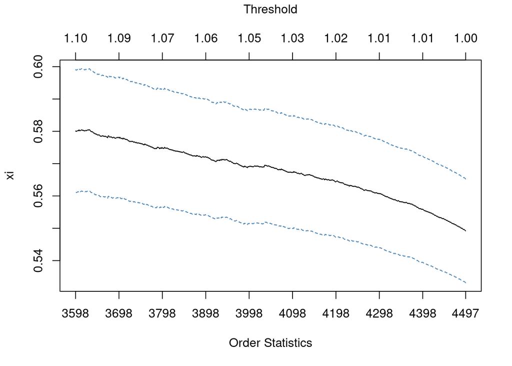

```r
hillPlot(apply(data.stand,1,min), start=0.8*n, plottype="xi")
```

The values estimated for eta, and the upper confidence bound far below 1, strongly suggest that we have joint asymptotic independence for these 5 variables.

## Practicals Part 3: Modeling extremal dependence in air pollution data

### 3.1) Empirical estimation of the angular measure

We first construct the pseudo-polar coordinates and then extract the angles w corresponding to extreme events.

```r
r.obs=apply(data.stand,1,sum)
w.obs=data.stand/r.obs
r_0=quantile(r.obs,0.95)
w.H=w.obs[r.obs>r_0,]
```

### 3.2) Estimation of joint exceedances above the overall 95% quantile

```r
q95=quantile(mydata,0.95)
q95
```

```
##      95%
## 60.57925
```

```r
prob.component=apply(mydata<q95,2,mean)
u.star=1/(1-prob.component)
u.star
```

```
##      alx      arl       mc       rt       ts
## 16.77985 19.63755 23.18041 15.89046 29.78146
```

```r
ell.min=function(w,u){min(w/u)} #already defined in preceding exercice
d=5
n_0=nrow(w.H)
#estimate the probability of the joint exceedance event:
d/n_0*sum(apply(w.H,1,ell.min,u=u.star))
```

```
## [1] 0.00932001
```

```r
#compare to observed empirical probability:
mean(apply(t(t(data.stand)/u.star)>1,1,all))
```

```
## [1] 0.008005337
```

In this case, we see that the estimate is relatively close to the empirically observed value. Note that the estimate based on the spectral measure uses more data for the estimation and has therefore much less estimation variance than the direct empirical estimate, which can be very variable depending on the dataset.

### 3.3) Estimation of a parametric Dirichlet model for the angular measure

We first define the log-likelihood function, and then use it within the maxLik function to compute the maximum likelihood estimate.

```r
library(MCMCpack) #for Dirichlet density
library(maxLik) #for numerical maximisation of the log-likelihood
```

```r
#define the log-likelihood function:
llfun=function(alpha){
if(alpha<=0) return(-Inf) #inadmissible parameters
 sum(log(ddirichlet(w.H,alpha=rep(alpha,d))))
}

initpar=1 # define the initial value of the parameter
fit=maxLik(llfun,start=initpar)
summary(fit)
```

```
## --------------------------------------------
## Maximum Likelihood estimation
## Newton-Raphson maximisation, 5 iterations
## Return code 1: gradient close to zero (gradtol)
## Log-Likelihood: 746.2337
## 1  free parameters
## Estimates:
##      Estimate Std. error t value Pr(> t)
## [1,]  0.74182    0.02923   25.38  <2e-16 ***
## ---
## Signif. codes:  0 '***' 0.001 '**' 0.01 '*' 0.05 '.' 0.1 ' ' 1
## --------------------------------------------
```

Here the estimated Dirichlet shape parameter is 0.74.

### 3.4) Pairwise estimations of the Huesler-Reiss dependence parameters

We construct a dooble loop to run through all combinations of two different variables and estimate the corresponding Huesler-Reiss distributions.

First, we load the required R packages.

```r
library(evd)
```

```r
u=quantile(mydata,0.95)
Lambda=matrix(0,d,d)
for(j1 in 1:(d-1)){
  for(j2 in (j1+1):d){
    fit.bv=fbvpot(mydata[,c(j1,j2)],threshold=c(u,u),model="hr")
    Lambda[j1,j2]=Lambda[j2,j1]=1/fit.bv$estimate[5]
  }
}
Lambda
```

```
##           [,1]      [,2]      [,3]      [,4]      [,5]
## [1,] 0.0000000 0.5909368 0.9416017 0.8368874 1.0609385
## [2,] 0.5909368 0.0000000 0.8285308 0.7755702 0.9347746
## [3,] 0.9416017 0.8285308 0.0000000 0.8605284 0.8040031
## [4,] 0.8368874 0.7755702 0.8605284 0.0000000 0.9323940
## [5,] 1.0609385 0.9347746 0.8040031 0.9323940 0.0000000
```

Some differences arise in the estimated values. We estimate the strongest extremal dependence between components 1 and 2, and the weakest extremal dependence between components 1 and 5. We could also check the standard errors of these estimates to see if these differences are significant.